# 141a final project

2026-03-16

Notes: Download link of datasets used in this report: NOAA Temperature and Precipitation datasets are available in this link: https://www.ncei.noaa.gov/data/nclimgrid-monthly/access/ The temperature dataset is the nclimgrid_tavg.nc file, and the precipitation dataset is the nclimgrid_prcp.nc file. For the Kaggle “1.88 Million US Wildfires” dataset, the file is available in the github link or on this website https://www.kaggle.com/datasets/rtatman/188-million-us-wildfires/data

# Abstract

The project develops predictive models for the occurrence of major wildfires in the contiguous United States. The project uses the dataset “1.88 Million US Wildfires” from Kaggle, and defines a major wildfire as a fire larger than 300 acres. I organize the wildfire records into a county-month panel dataset and create a binary outcome to represent whether at least one major wildfire occurred in a given county during a given month. To improve the models’ predictive performance, I introduced two climate variables monthly average temperature and monthly average precipitation from the NOAA NClimGrid dataset. I constructed and compared three prediction models, including logistic regression, random forest, and XGBoost. I divided the dataset from 1992 to 2010 as training set and data from 2011 to 2015 as the testing set. Model performance is evaluated using the Area Under the ROC Curve (AUC) and sensitivity (the proportion of actual major wildfires that are correctly predicted by the model) under the same cutoff. The XGBoost model shows the strongest predictive performance under both evaluation standards.

# Data Preprocessing

First I read the full wildfire dataset “1.88 Million US Wildfires.” from Kaggle. The dataset has 1880465 rows and 39 columns. The data contains historical wildfire records across United States, including information such as locations, discovery dates, containment dates, and burned area.

```
## [1] 1880465      39
```

Variables about fire size, time, and space could be important for constructing our county-month panel data.

For time related variables, there are DISCOVERY_DATE, DISCOVERY_DOY, and DISCOVERY_TIME. DISCOVERY_DATE is the calendar date on which the wildfire was discovered, and it’s stored in Julian date format. DISCOVERY_DOY gives the day of the year when the fire was discovered, and DISCOVERY_TIME is the hour and minute of discovery. I will primarily use DISCOVERY_DATE in our analysis.

There are not any missing values in variable DISCOVERY_DATE. I transfer the Julian format to a Year/Month/Date format variable date. Two variables year and month are extracted from date. We can see the minimum value of year is 1992, and maximum value of year is 2015. So the dataset covers wildfire data from 1992 to 2015.

```r
library(dplyr)
library(lubridate)
wildfire = wildfire %>%
  mutate( date = as.Date(DISCOVERY_DATE -2440587.5, origin = "1970-01-01"), year =year(date), month =month(date))

# The year. month, and data information of the first wildfire observation
wildfire$year[1];wildfire$month[1];wildfire$date[1]
```

```
## [1] 2005
```

```
## [1] 2
```

```
## [1] "2005-02-02"
```

```r
min(wildfire$year)
```

```
## [1] 1992
```

```r
max(wildfire$year)
```

```
## [1] 2015
```

For space related variables, there are STATE, COUNTY, and FIPS_CODE. STATE is the state where the wildfire occurred, recorded using two-letter state abbreviation (such as CA). COUNTY identifies the county name where the wildfire was reported. FIPS_CODE is the 3-digit county-level Federal Information Processing Standards code, which is a geographic identifier for each county. Among the wildfires dataset, 678148 rows have missing values for both COUNTY and FIPS_CODE.

```r
sum(is.na(wildfire$STATE))
```

```
## [1] 0
```

```r
sum(is.na(wildfire$FIPS_CODE))
```

```
## [1] 678148
```

```r
sum(is.na(wildfire$COUNTY))
```

```
## [1] 678148
```

```r
sum(is.na(wildfire$FIPS_CODE) & is.na(wildfire$COUNTY))
```

```
## [1] 678148
```

```r
sum(is.na(wildfire$COUNTY) & !is.na(wildfire$FIPS_CODE))
```

```
## [1] 0
```

```r
library(dplyr)
library(tidyr)
library(lubridate)

wildfire_clean = wildfire %>%
  filter(!is.na(FIPS_CODE))

wildfire_clean = wildfire_clean %>%
  mutate(large_fire = ifelse(FIRE_SIZE >= 300, 1, 0)) #define major fire
```

In this study, I choose to use FIPS_CODE to define the spatial unit as it’s a more standardized identifier for county compared to COUNTY. COUNTY variable in this dataset, on the other hand, has both character values like “Lincoln” and numeric values like “5”. Since county information is necessary for further analysis, and wildfire records without county information can’t be mapped into a county-month panel data, rows with missing FIPS_CODE cannot be assigned to a spatial unit and thus are removed.

Because FIPS_CODE in this dataset is only a three-digit county-level code, and there are over 3000 counties in the US. As a result, counties in different states could have the same three-digit FIPS_CODE, but they are two places in different states. Now we turn the 3 digit FIP_CODE in our wildfire dataset to 5 digit (2-digit state + 3-digit county) to better distinguish states from different states with the same FIP_CODE. Later I will merge a climate dataset with the county-month dataset, and for the climate data, the FIPS codes are also in 5 digits (2-digit state + 3-digit county). So this step can also help with the data merge in the next step.

It’s also worth mentioning that there are 3108 counties in the contiguous US in 2015, but our clean wildfire dataset only records wildfire information for 2795 counties. I think the major reason is because we removed 678148 rows with insufficient county information from original Kaggle dataset. These dropped records also correspond to real wildfire events, but I can’t assign them to a county and therefore they can’t be used in a county-level panel. If I constructed a county-month panel dataset for all contiguous U.S. counties, I would have to treat counties missing from the cleaned dataset as having no wildfire activity, and this could be incorrect given I removed wildfire activities with no county identifier. As a result, I restrict the analysis to counties that can be identified in the wildfire dataset. Regions that are not in contiguous United States, such as Hawaii, Alaska, Guam, and Puerto Rico, are excluded from the study. These noncontiguous US territories could have significantly different geographies, climates and wildfire occurrences than the contiguous US, so we exclude them from our analysis.

```
## in your R script or .Rprofile.
```

```r
n_distinct(wildfire_clean$FIPS_CODE)
```

```
## [1] 2795
```

```r
nrow(counties(cb = TRUE,year = 2015))
```

```
## [1] 3233
```

For the fire size information, here are the 50, 75, 90, 95, and 99 quantiles of fire size in this dataset and the max value of fire size. FIRE_SIZE is this dataset refers to the estimates of acres within the final perimeter of the fire.

```
##      50%      75%      90%      95%      99%     100%
##      1.0      3.3     17.0     45.0    460.0 606945.0
```

As we can see, the wildfire records in this dataset are mostly fires that are very small and are quickly contained after ignition. Including all fires in the analysis would place most of the modeling weight on small incidents that have limited importance. To better focus on fires that are meaningful, I first create a binary variable large_fire that indicates if the fire size of a wildfire is larger than or equal to 300 acres. I choose this threshold because U.S. fire management agencies define fires with 300 acres in grass or brush fuel models as large wildland fires. I then aggregate the data to my county-month panel dataset and define my binary outcome variable “occur” to indicate if at least one major fire occurs in a given county-month.

I use FIPS_CODE together with the extracted month variable to construct the county-by-month dataset.

```r
county_month_fire = wildfire_clean %>%
  group_by(FIPS_CODE, year, month) %>%
  summarise(occur = as.integer(any(large_fire == 1)),.groups = "drop")

county_month_data = observed_counties %>%
  crossing(all_months) %>%
  left_join(county_month_fire, by = c("FIPS_CODE", "year", "month")) %>%
  mutate(occur = ifelse(is.na(occur), 0, occur))
```

For prediction purposes, I will create several predictors. I think historical wildfire activity might provide useful predictive signals for wildfire activity this month. Counties with frequent wildfires in the past may be more likely to have another wildfire in the current month. As a result, I constructed several lagged wildfire indicators as predictors, including lag1_fire (whether a major fire happened last month in this county), past12_majorfire_count (how many major fires happened in the last year in this county), lag12_fire (whether a major wildfire occurred in the same month last year in this county), and past12_lightning_fire_count (how many major fires were caused by lightning in the past year).

```r
library(slider)
county_month_data = county_month_data %>%
  arrange(FIPS_CODE, year, month) %>%
  group_by(FIPS_CODE) %>%
  mutate(lag1_fire = lag(occur, 1, default = 0),
         lag12_fire = lag(occur, 12, default = 0),
         past12_majorfire_count = slider::slide_dbl(
           lag(occur, 1),sum,.before = 11,.complete = FALSE)) %>%
  ungroup()
```

```r
library(dplyr)

lightning_month = wildfire_clean %>%
  mutate(lightning_major = ifelse(large_fire == 1 & STAT_CAUSE_DESCR == "Lightning", 1, 0)) %>%
  group_by(FIPS_CODE,  year, month) %>%
  summarise(lightning_major_fire_count = sum(lightning_major),.groups = "drop")

county_month_data = county_month_data %>%
  left_join(lightning_month, by = c("FIPS_CODE","year","month")) %>%
  mutate(lightning_major_fire_count = replace_na(lightning_major_fire_count,0)) %>%
  mutate(past12_majorfire_count = replace_na(past12_majorfire_count,0))
```

```r
county_month_data = county_month_data %>%
  arrange(FIPS_CODE, year, month) %>% group_by(FIPS_CODE) %>%
  mutate( past12_lightning_fire_count = slider::slide_dbl(
    lag(lightning_major_fire_count,1),~sum(.x, na.rm = TRUE),.before = 11,.complete = FALSE)) %>%
  ungroup()
head(county_month_data)
```

```
## # A tibble: 6 × 9
##   FIPS_CODE  year month occur lag1_fire lag12_fire past12_majorfire_count
##   <chr>     <dbl> <dbl> <dbl>     <dbl>      <dbl>                  <dbl>
## 1 01001      1992     1     0         0          0                      0
## 2 01001      1992     2     0         0          0                      0
## 3 01001      1992     3     0         0          0                      0
## 4 01001      1992     4     0         0          0                      0
## 5 01001      1992     5     0         0          0                      0
## 6 01001      1992     6     0         0          0                      0
## # ℹ 2 more variables: lightning_major_fire_count <dbl>,
## #   past12_lightning_fire_count <dbl>
```

Climate conditions are also strongly associated with wildfire occurrence. As the wildfire dataset lacks these important factors, to incorporate environmental variables, I use monthly climate variables from the NOAA NClimGrid dataset, including mean temperature and precipitation. These variables are aggregated to the county-by-month level and merged with the wildfire dataset.

```r
library(terra)
tavg = rast("/Users/macbookxie/Downloads/nclimgrid_tavg.nc")

# keep only time that also contains data in the wildfire dataset
tavg_time = tavg[[time(tavg) >= "1992-01-01" & time(tavg) <= "2015-12-01"]]
prcp = rast("/Users/macbookxie/Downloads/nclimgrid_prcp.nc")
prcp_time = prcp[[time(prcp) >= "1992-01-01" & time(prcp) <= "2015-12-01"]]
```

```r
library(sf)
library(tigris)
library(exactextractr)

# 288 layers because 12 (month) * 24 (years) = 288
nlyr(tavg_time);nlyr(prcp_time)
```

```
## [1] 288
```

```
## [1] 288
```

```r
# create year-month index for climate dataset

dates = seq(as.Date("1992-01-01"), as.Date("2015-12-01"), by = "month")
climate_index = data.frame( layer = 1:length(dates), date =dates,
                            year = as.integer(format(dates, "%Y")),month = as.integer(format(dates, "%m")))

# rename layers in the given format for use later
names(tavg_time) = paste0("tavg_", climate_index$year, "_", sprintf("%02d", climate_index$month))
names(prcp_time) = paste0("prcp_", climate_index$year, "_", sprintf("%02d", climate_index$month))
```

```r
tavg_county = bind_cols(
  counties %>% st_drop_geometry() %>% select(FIPS_CODE, NAME),
  as.data.frame(tavg_county)
)

prcp_county = bind_cols(
  counties %>% st_drop_geometry() %>% select(FIPS_CODE, NAME),
  as.data.frame(prcp_county)
)

names(tavg_county) = gsub("^mean\\.", "", names(tavg_county))
names(prcp_county) = gsub("^mean\\.", "", names(prcp_county))
```

```r
library(tidyr)

tavg_long = tavg_county %>%
  pivot_longer(cols = starts_with("tavg_"),
               names_to = c("year", "month"),
               names_pattern = "tavg_(\\d{4})_(\\d{2})",
               values_to = "tavg") %>%
  mutate(year = as.integer(year),
         month = as.integer(month)) %>%
  select(FIPS_CODE, county_name = NAME, year, month, tavg)

prcp_long = prcp_county %>%
  pivot_longer(cols = starts_with("prcp_"),
               names_to = c("year", "month"),
               names_pattern = "prcp_(\\d{4})_(\\d{2})",
               values_to = "prcp") %>%
  mutate(year = as.integer(year),
         month = as.integer(month)) %>%
  select(FIPS_CODE, county_name = NAME, year, month, prcp)

climate = tavg_long %>%
  left_join(prcp_long, by = c("FIPS_CODE",  "county_name", "year", "month"))

model_data = county_month_data %>%
  left_join(climate, by = c("FIPS_CODE",  "year", "month"))

# model data clean is model data with no missing values for temperature and precipitation
model_data_clean = model_data %>%
  filter(!is.na(tavg), !is.na(prcp))
```

After merging the wildfire dataset with the climate dataset, 8064 county–month observations (around 1% of all county-month observations) have missing values in the climate variables (tavg and prcp). Models that include climate predictors would require complete values for tavg and prcp. Therefore, I conduct the analysis using county–month observations with non-missing climate data.

the final modeling dataset contains 796,896 county–month observations. The spatial unit is the county identified by a 5-digit FIPS code, and the temporal unit is month. The unit of temperature is Degree Celsius, and the unit of precipitation is millimeters. The dataset covers the period from 1992 to 2015.

The outcome variable is a binary variable indicating whether at least one notable wildfire (≥300 acres) occurred in a county during a given month. Below is a summary of our modeling dataset.

```r
dataset_summary = tibble(
  Item = c(
    "Number of observations",
    "Number of counties",
    "Years covered",
    "Spatial unit",
    "Temporal unit",
    "Outcome definition",
    "Major fire rate",
    "Climate missing rate",
    "Predictors included"
  ),
  Value = c(
    nrow(model_data_clean),
    n_distinct(model_data_clean$FIPS_CODE),
    paste(min(model_data_clean$year), "-", max(model_data_clean$year)),
    "County (5-digit FIPS code)",
    "Month",
    "1 if at least one wildfire >= 300 acres occurred in a given county-month",
    paste0(round(mean(model_data_clean$occur) * 100, 5), "%"),
    paste0(round(mean(is.na(model_data$tavg)) * 100, 5), "%"),
    "Temperature, precipitation, lag1 fire, lag12 fire, past12 major fire count, past12 lightning fire count"
  )
)

dataset_summary
```

```
## # A tibble: 9 × 2
##   Item                   Value
##   <chr>                  <chr>
## 1 Number of observations 796896
## 2 Number of counties     2767
## 3 Years covered          1992 - 2015
## 4 Spatial unit           County (5-digit FIPS code)
## 5 Temporal unit          Month
## 6 Outcome definition     1 if at least one wildfire >= 300 acres occurred in a …
## 7 Major fire rate        1.22412%
## 8 Climate missing rate   1.00179%
## 9 Predictors included    Temperature, precipitation, lag1 fire, lag12 fire, pas…
```

# Exploratory Data Analysis

### 1. Wildfire Seasonality Plot

The probability of major wildfires is different in different months. Fire incidence tends to be high during the summer months (June, July, August) . This seasonal pattern suggests that month could be a useful predictor in the classification models. Also, it inspires me to discover if the relationship between major wildfire and month is the same across all states, or different states with different climates could show different relationships.

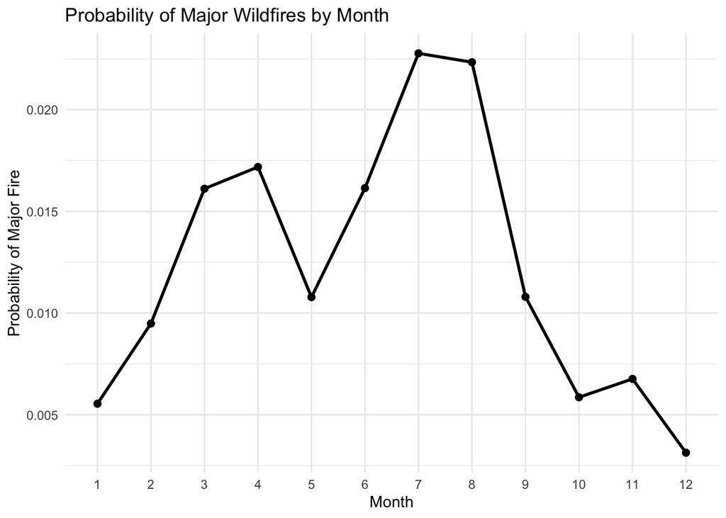

```r
library(ggplot2)
library(dplyr)

monthly_fire = model_data_clean %>%
  group_by(month) %>%
  summarise(fire_rate = mean(occur), .groups = "drop") %>%
  mutate( month = factor(month, levels = 1:12))

ggplot(monthly_fire, aes(x = month, y = fire_rate, group = 1)) +
  geom_line(size = 1) +
  geom_point(size = 2) +
  labs(title = "Probability of Major Wildfires by Month",
       x = "Month",
       y = "Probability of Major Fire") +
  theme_minimal()
```

### Wildfire Seasonality Plot in different States

To see whether the seasonality plot of wildfires is different across different states, I picked Arizona (Southwest), Florida (South), California (West), and Texas. From the plot, we can see that the seasonality of major wildfires differs a lot in different states. For Florida, fire rates are highest during January to June, and in summer and winter times the major fire rate is significantly lower. For Arizona, the fire rate peaks during May to August, which is consistent with the national pattern. For California, the fire rates are high during May to October, and the fire rate in other months is much lower. For Texas, we see two peaks for fire rate, one in March and one in August. To study reasons for the dual peak pattern in Texas, I analyze the reasons for wildfire occurrence for the major wildfires in Texas in the next plot.

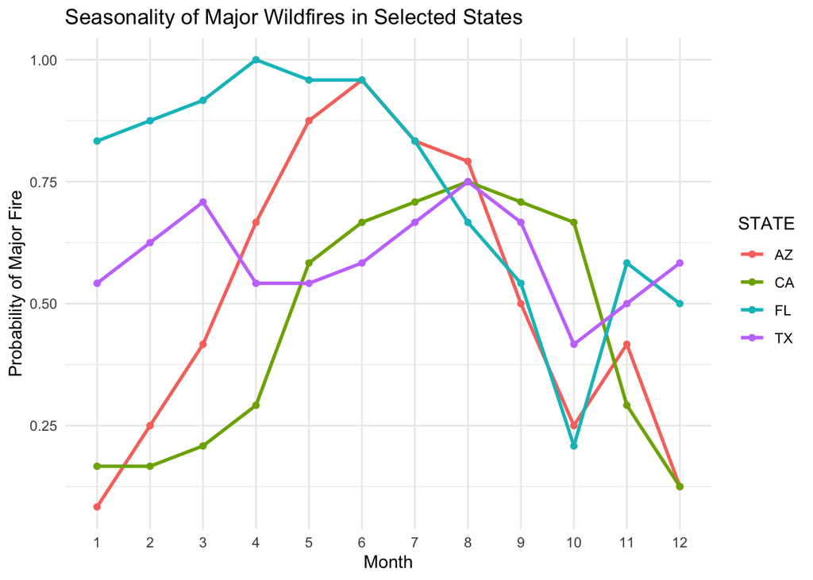

```r
library(tigris)
library(sf)

library(dplyr)

# first design this state_month panel dataset for this plot and plots later
state_month_fire = wildfire_clean %>%
  group_by(STATE, year, month) %>%
  summarise( state_occur = as.integer(any(large_fire == 1)),
             .groups = "drop")

all_states = wildfire_clean %>% distinct(STATE)

all_state_months = all_states %>%
  crossing( year = sort(unique(wildfire_clean$year)),
            month = 1:12)

state_month_panel = all_state_months %>%
  left_join(state_month_fire, by = c("STATE", "year", "month")) %>%
  mutate(state_occur = ifelse(is.na(state_occur), 0, state_occur))

state_fire_rate = state_month_panel %>%
  group_by(STATE) %>%
  summarise(fire_rate = mean(state_occur),
            .groups = "drop") %>%
  arrange(desc(fire_rate))

state_month = state_month_panel %>%
  filter(STATE %in% c("CA","FL","AZ","TX")) %>%
  group_by(STATE, month) %>%
  summarise(
    fire_rate = mean(state_occur),
    .groups="drop"
  ) %>%
  mutate(month = factor(month, levels = 1:12))


ggplot(state_month,
       aes(x = month, y = fire_rate, color = STATE, group = STATE)) +
  geom_line(size = 1) +
  geom_point() +
  labs(title = "Seasonality of Major Wildfires in Selected States",
       x = "Month",
       y = "Probability of Major Fire") +
  theme_minimal()
```

### Major Wildfire Causes in Texas

To understand the dual peaks of major fire rates in Texas, I draw a plot of the common causes of major wildfires across different months. We can see the human-related causes (Miscellaneous, Equipment use, debris burning) are highest during January and April, while natural causes (lightning) are highest during June and August. As a result, we can see that the spring major fire rate peak is likely due to human activities, while the summer peak appears to come from lightning-caused fires. Higher temperature and drier conditions in summer could be associated with higher major fire rates in Texas during summer.

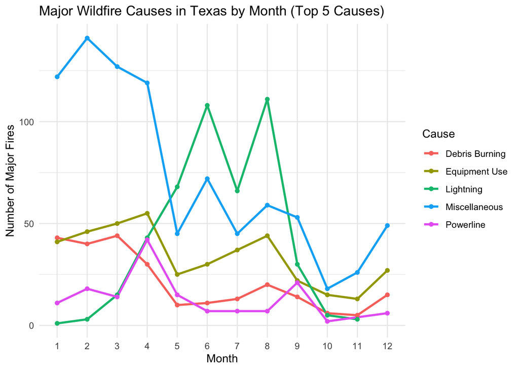

```r
library(dplyr)
library(ggplot2)

top_causes = wildfire_clean %>%
  filter(STATE == "TX", large_fire == 1) %>%
  count(STAT_CAUSE_DESCR, sort = TRUE) %>%
  slice_head(n = 5) %>%
  pull(STAT_CAUSE_DESCR)

tx_cause_month = wildfire_clean %>%
  filter(STATE == "TX", large_fire == 1,
         STAT_CAUSE_DESCR %in% top_causes) %>%
  group_by(month, STAT_CAUSE_DESCR) %>%
  summarise(count = n(), .groups="drop")

ggplot(tx_cause_month,
       aes(x = factor(month), y = count,
           color = STAT_CAUSE_DESCR, group = STAT_CAUSE_DESCR)) +
  geom_line(size = 1) +
  geom_point() +
  labs(title = "Major Wildfire Causes in Texas by Month (Top 5 Causes)",
       x = "Month",
       y = "Number of Major Fires",
       color = "Cause") +
  theme_minimal()
```

### Major Wildfire Causes in Florida

I do a similar plot for Florida, looking at the common causes of major wildfires across different months in Florida. The result shows that lightning is the single dominant cause of major wildfires in Florida, and lightning-caused wildfires peak at June. We see the major fire rate in Florida is high across January to June, likely because in January to April, human-caused major wildfire rates is much higher than other months of the year.

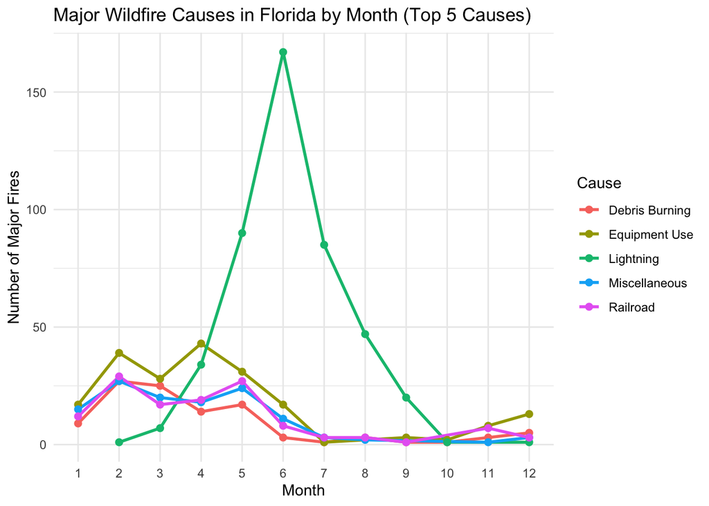

```r
library(dplyr)
library(ggplot2)

top_causes_fl = wildfire_clean %>%
  filter(STATE == "FL", large_fire == 1) %>%
  count(STAT_CAUSE_DESCR, sort = TRUE) %>%
  slice_head(n = 5) %>%
  pull(STAT_CAUSE_DESCR)

fl_month = wildfire_clean %>%
  filter(STATE == "FL", large_fire == 1,
         STAT_CAUSE_DESCR %in% top_causes_fl) %>%
  group_by(month, STAT_CAUSE_DESCR) %>%
  summarise(count = n(), .groups = "drop") %>%
  mutate(month = factor(month, levels = 1:12))

ggplot(fl_month,
       aes(x = month, y = count,
           color = STAT_CAUSE_DESCR, group = STAT_CAUSE_DESCR)) +
  geom_line(linewidth = 1) +
  geom_point(size = 2) +
  labs(title = "Major Wildfire Causes in Florida by Month (Top 5 Causes)",
       x = "Month",
       y = "Number of Major Fires",
       color = "Cause") +
  theme_minimal()
```

### Major Wildfire Causes in California

I do a similar plot in California. From the plot, we can also see that the lightning has been the dominant driver of major wildfires in California. Unlike Florida and Texas, human-caused wildfires in California also peak at summer times. From the plots above, I conclude that wildfire seasonality and major causes of wildfires are different across different states. These observations also suggest that wildfire occurrence could depend on complex relationships between climate conditions and fire causes, indicating that use of more nonlinear models may capture the relationships better than linear models.

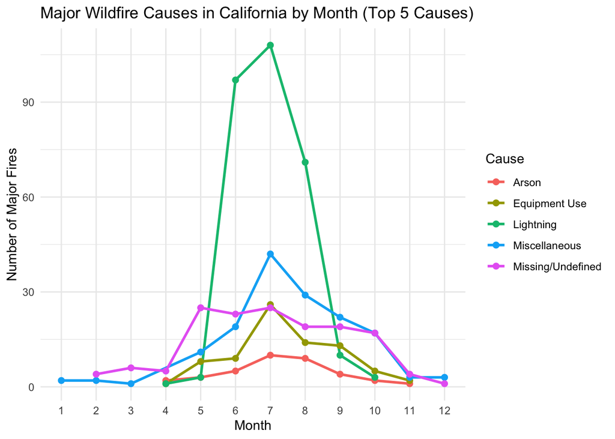

```r
library(dplyr)
library(ggplot2)

top_causes_ca = wildfire_clean %>%
  filter(STATE == "CA", large_fire == 1) %>%
  count(STAT_CAUSE_DESCR, sort = TRUE) %>%
  slice_head(n = 5) %>%
  pull(STAT_CAUSE_DESCR)

ca_month = wildfire_clean %>%
  filter(STATE == "CA", large_fire == 1,
         STAT_CAUSE_DESCR %in% top_causes_ca) %>%
  group_by(month, STAT_CAUSE_DESCR) %>%
  summarise(count = n(), .groups = "drop") %>%
  mutate(month = factor(month, levels = 1:12))

ggplot(ca_month,
       aes(x = month, y = count,
           color = STAT_CAUSE_DESCR,
           group = STAT_CAUSE_DESCR)) +
  geom_line(linewidth = 1) +
  geom_point(size = 2) +
  labs(title = "Major Wildfire Causes in California by Month (Top 5 Causes)",
       x = "Month",
       y = "Number of Major Fires",
       color = "Cause") +
  theme_minimal()
```

### 2. Temperature vs. wildfire probability

Here I divide the temperature range (-22.74 to 35.68 degrees) into 10 bins and calculate the average major fire rate at each bin. The major fire rate for temperatures under -5.21 is close to zero. For temperature range 29.8 - 35.7, the major fire rate is much higher than other temperature bins, indicating that major fires are most likely occur at this temperature.

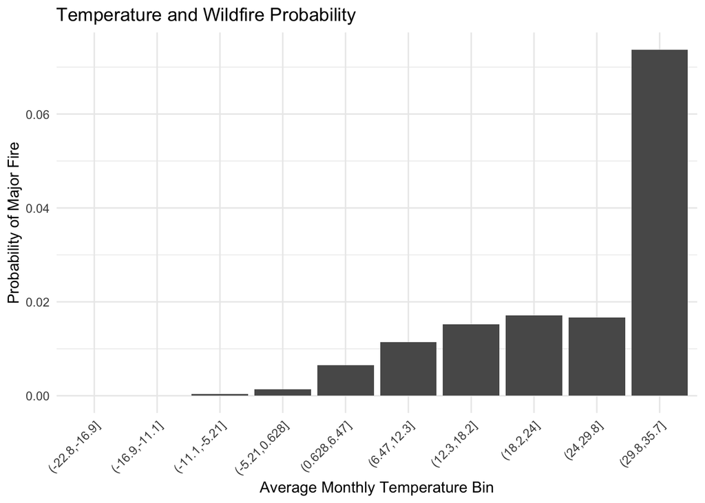

```r
library(ggplot2)

temp_bins = model_data_clean %>%
  mutate(temp_bin = cut(tavg, breaks = 10)) %>%
  group_by(temp_bin) %>%
  summarise(fire_rate = mean(occur))

ggplot(temp_bins, aes(x = temp_bin, y = fire_rate)) +
  geom_col() +
  labs(title = "Temperature and Wildfire Probability",
       x = "Average Monthly Temperature Bin",
       y = "Probability of Major Fire") +
  theme_minimal() +
  theme(axis.text.x = element_text(angle = 45, hjust = 1))
```

### 3. Precipitation vs. wildfire probability

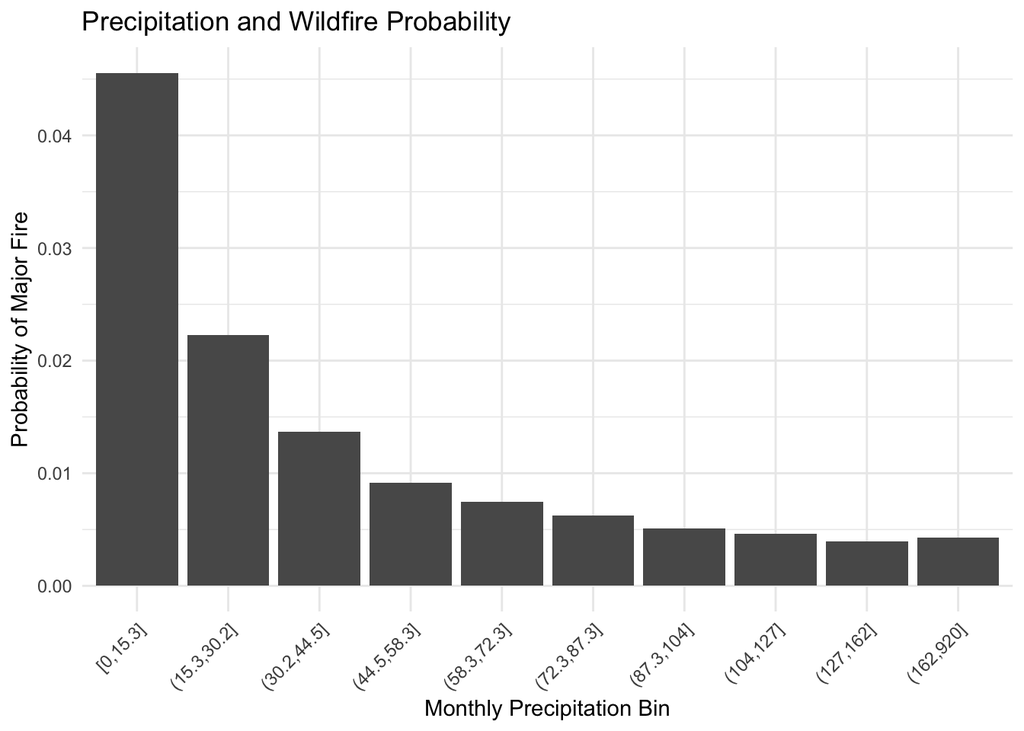

```r
library(dplyr)
library(ggplot2)

# design the bin width by percentiles
prcp_bins = model_data_clean %>%
  mutate( prcp_bin = cut(prcp, breaks = quantile(prcp, probs = seq(0, 1, by = 0.1), na.rm = TRUE), include.lowest = TRUE)) %>%
  group_by(prcp_bin) %>%
  summarise(fire_rate = mean(occur),.groups = "drop")

ggplot(prcp_bins, aes(x = prcp_bin, y = fire_rate)) +
  geom_col() +
  labs( title = "Precipitation and Wildfire Probability",
        x = "Monthly Precipitation Bin",
        y = "Probability of Major Fire") +
  theme_minimal() +
  theme(axis.text.x = element_text(angle = 45, hjust = 1))
```

### 4. Spatial Pattern of Major Fires

To see the spatial pattern of major fires in the US, I draw the continental US map and color each county with its average monthly probability of major fire. The plot shows spatial variation in average monthly probability of major fire across the continental US. There are some blank regions in the plot, because the county-month panel dataset only contains counties that are identified in the cleaned wildfire records. We can see from the plot that some counties in the western United States (especially counties in Nevada and Idaho) tend to have high average monthly probability of major fire. Florida also appears to be a state with frequent major wildfires. To more clearly visualize which state has the most frequent major wildfires, for each state, I computed the average proportion of months that have major wildfire occurrence.

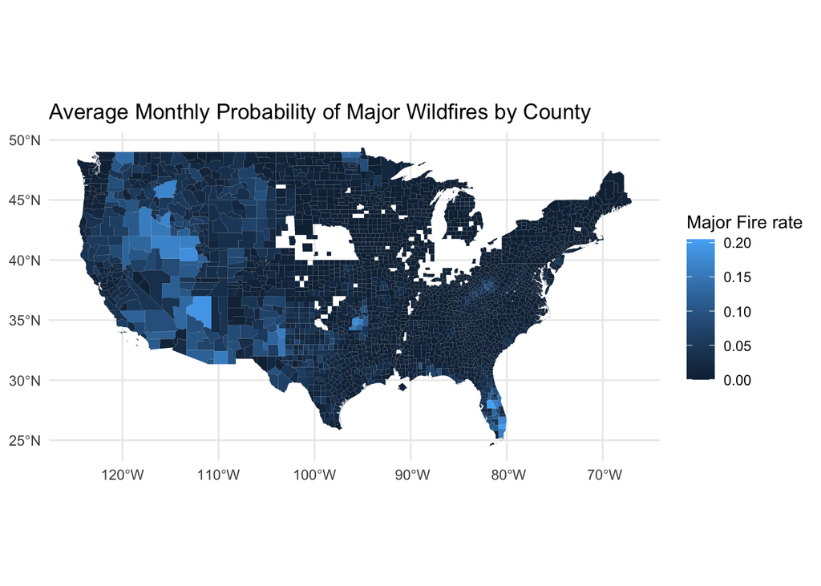

```r
library(dplyr)
library(sf)
library(tigris)
library(ggplot2)

county_avg_fire = model_data_clean %>%
  group_by(FIPS_CODE) %>%
  summarise(avg_fire_rate = mean(occur, na.rm = TRUE))

us_counties = counties(cb = TRUE, year = 2015, class = "sf") %>%
  filter(!STATEFP %in% c("02", "15", "60", "66", "69", "72", "78")) %>%
  mutate(FIPS_CODE = GEOID) %>%
  inner_join(county_avg_fire, by = "FIPS_CODE")

ggplot(us_counties) +
  geom_sf(aes(fill = avg_fire_rate), color = NA) +
  labs(title = "Average Monthly Probability of Major Wildfires by County",
       fill = "Major Fire rate") +
  theme_minimal()
```

### 5. Average Monthly WildFire Rates

In this plot, I calculated the top10 states with the highest proportion of months that have at least one major fire occurance. Florida has the highest average monthly major fire rate, up to around 75%. Southern and Southwestern US states such as Utah, Arizona, Texas, and Oklahoma, and Western US States such as California, Oregon are all on the list, indicating that major wildfires are more frequent in the western and southern regions of the United States than in other parts of the country.

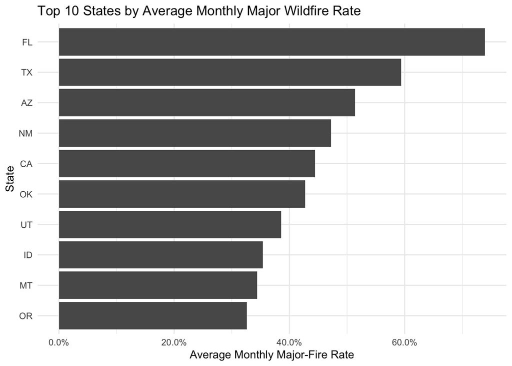

```r
library(dplyr)
library(ggplot2)
library(tigris)
library(sf)
library(dplyr)
library(ggplot2)
library(scales)
top10_states = state_fire_rate %>%
  slice_max(order_by = fire_rate, n = 10)

ggplot(top10_states, aes(x = reorder(STATE, fire_rate), y = fire_rate)) +
  geom_col() +
  coord_flip() +
  scale_y_continuous(labels = percent_format(accuracy = 0.1)) +
  labs(
    title = "Top 10 States by Average Monthly Major Wildfire Rate",
    x = "State",
    y = "Average Monthly Major-Fire Rate"
  ) +
  theme_minimal()
```

# 3. Modeling

### 1. Baseline Model (Logistic Regression)

The prediction model is to estimate whether at least one notable wildfire occurs in a specific county during a given month.

Because the Y variable “occur” is binary, I first use logistic regression as the baseline classification model. The predictors include month, monthly average temperature (tavg), monthly average precipitation (prcp), whether a major wildfire occurred in the previous month (lag1_fire), whether a major wildfire occurred in the same month of the previous year (lag12_fire), the number of major wildfires in the past 12 months (past12_majorfire_count), and the number of lightning-caused major wildfires in the past 12 months (past12_lightning_fire_count).

Logistic model provides a simple baseline model that’s easy to interpret. It examines how each predictor is associated with wildfire occurrence. It captures a linear relationship between my predictors and the log-odds of wildfire occurrence, so it may not be able to fully capture the complex nonlinear relationships.

Logistic regression produces an output of predicted probabilities. To convert the probabilities to binary prediction results, I need to choose a cutoff. Choice of cutoff values are discussed later in Model Fitting session.

The logistic regression model is written as

$$P(Y_{it}=1)=\frac{1}{1+\exp(-(\beta_0+ \beta_1 tavg\ + \beta_2 prcp\ +
\beta_3 lag1_fire_{it}+ \beta_4 lag12\_fire_{it} + \beta_5
past12\_majorfire\_count_{it} + \beta_6
past12\_lightning\_fire\_count_{it} +\gamma_{month}))}$$

where i indexes counties and t indexes months. Y{it} denotes whether at least one major wildfire occurs during month t at county i.

### 2. Random Forest Model

For my second model, I use a random forest model. Random forest is a machine learning method that builds a large number of decision trees using bootstrap samples of the training data. Then the model combines the predictions of each decision tree and determines the major wildfire occurrence probability by the proportion of trees that classify an observation as a wildfire event.

The predictors include month, monthly average temperature (tavg), monthly precipitation (prcp), whether a major wildfire occurred in the previous month (lag1_fire), whether a major wildfire occurred in the same month of the previous year (lag12_fire), the number of major wildfires in the past 12 months (past12_majorfire_count), and the number of lightning-caused major wildfires in the past 12 months (past12_lightning_fire_count).

Random forest model could be useful in our model because the relationship between our predictors could be nonlinear and involve interactions. From the EDA, we see that month and state could have interaction effects. Also, climate variables and wildfire activity causes could have interactions that are difficult to model with a linear model. As a result, the random forest model is used to provide an approach to detect nonlinear effects and interactions among predictors.

Another advantage of random forests is that they reduce overfitting by averaging predictions across many trees. It improves prediction stability compared with a single decision tree. Random forests can also automatically capture complex interactions among predictors without requiring explicit specification of interaction terms in the model.

### 3. XGBoost

As a third model, I use an XGBoost model to predict whether at least one major wildfire occurs at a given county-month. XGBoost is a gradient boosting method that builds decision trees sequentially. At each step, a new tree is added to improve prediction by focusing on the errors made by the previous trees. For this classification question, the model outputs the estimated probability that a county-month observation has at least one notable wildfire. I choose XGBoost because wildfire occurrence may depend on nonlinear relationships and interactions among predictors.

Compared with random forest model, which builds trees independently, gradient boosting builds trees sequentially and each new tree corrects the previous errors. This approach could lead to stronger predictive performance, especially in large datasets where sequential error correction can gradually improve predictive performances.

The predictors include month, monthly average temperature (tavg), monthly precipitation (prcp), whether a major wildfire occurred in the previous month (lag1_fire), whether a major wildfire occurred in the same month of the previous year (lag12_fire), the number of major wildfires in the past 12 months (past12_majorfire_count), and the number of lightning-caused major wildfires in the past 12 months (past12_lightning_fire_count).

# Model Fitting and Validation

First the dataset is divided into training set and testing set. Here the dataset can’t be randomly divided, as we can’t use data in 2014 to build prediction models and predict wildfire occurrence in 2013. As a result, I choose to use data from 1992–2010 as the training set and data from 2011–2015 as the testing set. By this method, I ensure that the time order of our classification model is correct, and the training set takes approximately 80% (79.17%) of the total dataset.

```r
train_data = model_data_clean %>% filter(year <= 2010)
test_data = model_data_clean %>%filter(year >= 2011)

train_data$month = factor(train_data$month)
test_data$month = factor(test_data$month)

nrow(train_data) / nrow(model_data_clean)
```

```
## [1] 0.7916667
```

### Logistic Regression

Logistic regression produces an output of predicted probabilities, and a cutoff is needed to convert the probabilities to binary prediction. In this study, I choose a cutoff of 0.05. It’s because major wildfire is very rare in county-month data, and if I choose the cutoff to be a larger value, such as 0.5, the baseline model will never predict major fires to happen. Another reason for using a small cutoff is that missing a major wildfire is more severe than producing a false alarm. So in my study of wildfire prediction, I consider correctly identifying major wildfire occurrences more important than perfectly classifying non-fire observations. For this reason, sensitivity (the proportion of actual major wildfire that is correctly predicted by the model) is one of the most important performance metrics considered in this study. A lower cutoff could help increase the sensitivity. Though the cutoff may not be optimal for each mdoel, I use the same cutoff across all models to make my comparison consistent and easy to explain.

Besides sensitivity, several other factors are considered to evaluate model performance, including specificity and precision. Specificity is the proportion of no-major-fire observations that are correctly classified as no-major-fire county-month. Precision is the proportion of predicted major wildfires that actually have major wildfire occurrences. Accuracy (the proportion of correct predictions made by the model) is often used as a standard to measure model performance, but only about 1.224% of all county-month observations have a major fire in our dataset, accuracy is not a reliable measure. A model can achieve high accuracy by only predicting no major wildfire for observations.

```r
sum(model_data_clean$occur == 1) / nrow(model_data_clean)
```

```
## [1] 0.01224125
```

In addition to confusion-matrix-based metrics, I will also report the Area Under the ROC Curve (AUC). AUC measures the model’s ability to distinguish between wildfire and non-wildfire observations across different probability thresholds, and thus provides a measure of model performance independent of what threshold value we choose.

```r
glm_fit = glm( occur ~ month + tavg + prcp + lag1_fire + lag12_fire +past12_majorfire_count + past12_lightning_fire_count,
               data = train_data, family = binomial())
```

```r
library(pROC)
cutoff = 0.05

test_data$glm_prob = predict(glm_fit, newdata = test_data, type = "response")
test_data$glm_pred_class = ifelse(test_data$glm_prob >= cutoff, 1, 0)

glm_cm = table( Prediction = factor(test_data$glm_pred_class, levels = c(1, 0),
                                    labels = c("predict major fire", "predict no major fire")),
                Actual = factor(test_data$occur, levels = c(0, 1),
                                labels = c("no major fire", "major fire")))

glm_cm
```

```
##                        Actual
## Prediction              no major fire major fire
##   predict major fire             5196       1115
##   predict no major fire        157993       1716
```

```r
TP = glm_cm[1,2] # True positive
TN = glm_cm[2,1] # True Negative
FP = glm_cm[1,1] # False positive
FN = glm_cm[2,2] # false negative

sensitivity = TP / (TP + FN)
specificity = TN / (TN + FP)
precision = TP / (TP + FP)

glm_auc = roc(test_data$occur, test_data$glm_prob)$auc
glm_auc
```

```
## Area under the curve: 0.845
```

### Random Forest

According to the description in modeling section, I fit the random forest model. In this model, I kept number of trees to 100 because of memory limitations. From the variable importance plots, we can tell that precipitation (prcp) and average temperature (tavg) are the two most important predictors in the random forest model. The number of major wildfires in the past twelve months (past12_majorfire_count), month, lag1_fire also contribute to the model.

```r
 library(randomForest)
train_data$occur_factor = factor(train_data$occur, levels = c(0, 1))
test_data$occur_factor = factor(test_data$occur, levels = c(0, 1))

rf_fit = randomForest(
  occur_factor ~ month + tavg + prcp + lag1_fire + lag12_fire +
    past12_majorfire_count + past12_lightning_fire_count,
  data = train_data,
  ntree = 100, #ntree= 100 for limited memory on my laptop
  importance = TRUE
)
```

```r
rf_pred = predict(rf_fit, newdata = test_data, type = "prob")
test_data$rf_prob = rf_pred[, "1"]

cutoff = 0.05
test_data$rf_pred_class = ifelse(test_data$rf_prob >= cutoff, 1, 0)

rf_cm = table(
  Prediction = factor(test_data$rf_pred_class,
                      levels = c(1, 0),
                      labels = c("predict major fire", "predict no major fire")),
  Actual = factor(test_data$occur,
                  levels = c(0, 1),
                  labels = c("no major fire", "major fire")))

rf_cm
```

```
##                        Actual
## Prediction              no major fire major fire
##   predict major fire             3333        917
##   predict no major fire        159856       1914
```

```r
TP_rf = rf_cm[1,2]
FP_rf = rf_cm[1,1]
TN_rf = rf_cm[2,1]
FN_rf = rf_cm[2,2]

sensitivity_rf = TP_rf / (TP_rf + FN_rf)
specificity_rf = TN_rf / (TN_rf + FP_rf)
precision_rf = TP_rf / (TP_rf + FP_rf)

rf_auc = roc(test_data$occur, test_data$rf_prob)$auc
rf_auc
```

```
## Area under the curve: 0.7128
```

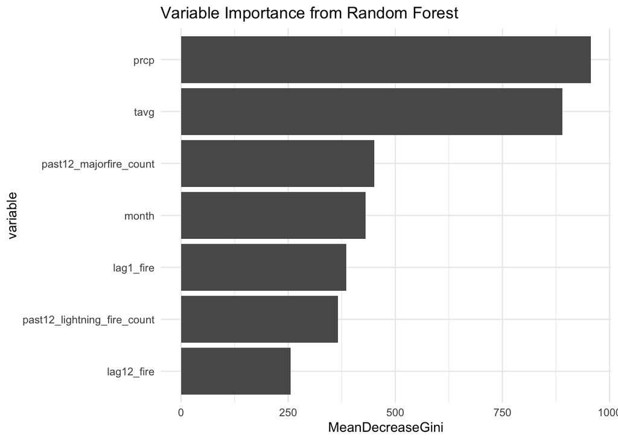

```r
library(dplyr)
library(ggplot2)
library(tibble)

rf_importance = importance(rf_fit) %>%
  as.data.frame() %>%
  rownames_to_column("variable")

rf_importance_gini = rf_importance %>%
  arrange(MeanDecreaseGini) %>%
  mutate(variable = factor(variable, levels = variable))

ggplot(rf_importance_gini,
       aes(x = variable, y = MeanDecreaseGini)) +
  geom_col() +
  coord_flip() +
  labs( title = "Variable Importance from Random Forest") +
  theme_minimal()
```

### XGBoost

The plot shows the feature importance results from my XGBoost Model. The values show the relative contribution of each feature to improving prediction accuracy. From the plot, we can see that the most important predictor in the XGBoost model is past12_majorfire_count, indicating that recent wildfire activity is the strongest signal for predicting future major wildfire events. Climate variables (temperature and precipitation) are also very important in predicting wildfire risks.

```r
library(xgboost)
library(pROC)
library(dplyr)

train_y = factor(train_data$occur, levels = c(0, 1))
test_y  = factor(test_data$occur, levels = c(0, 1))

train_matrix = model.matrix(
  ~ month + tavg + prcp + lag1_fire + lag12_fire +
    past12_majorfire_count + past12_lightning_fire_count,
  data = train_data
)[, -1]


xgb_fit = xgboost(
  x = train_matrix,
  y = train_y,
  objective = "binary:logistic",
  nrounds = 150, # use 150 boosting iterations
  max_depth = 4, # use small trees to limit overfitting
  learning_rate = 0.05, # small step size for stable learning
  eval_metric = "auc", # evaluate performance using auc
  verbosity = 0
)

test_matrix = model.matrix(
  ~ month + tavg + prcp + lag1_fire + lag12_fire +
    past12_majorfire_count + past12_lightning_fire_count,
  data = test_data
)[, -1]

test_data$xgb_prob = predict(xgb_fit, test_matrix)
```

```r
cutoff = 0.05

test_data$xgb_pred_class = ifelse(test_data$xgb_prob >= cutoff, 1, 0)

xgb_cm = table(
  Prediction = factor(
    test_data$xgb_pred_class,
    levels = c(1, 0),
    labels = c("predict major fire", "predict no major fire")
  ),
  Actual = factor(
    test_data$occur,
    levels = c(0, 1),
    labels = c("no major fire", "major fire")
  )
)

xgb_cm
```

```
##                        Actual
## Prediction              no major fire major fire
##   predict major fire             8208       1402
##   predict no major fire        154981       1429
```

```r
TP_xgb = xgb_cm[1,2]
FP_xgb = xgb_cm[1,1]
TN_xgb = xgb_cm[2,1]
FN_xgb = xgb_cm[2,2]

sensitivity_xgb = TP_xgb / (TP_xgb + FN_xgb)
specificity_xgb = TN_xgb / (TN_xgb + FP_xgb)
precision_xgb = TP_xgb / (TP_xgb + FP_xgb)

xgb_auc = roc(test_data$occur, test_data$xgb_prob)$auc
xgb_auc
```

```
## Area under the curve: 0.8693
```

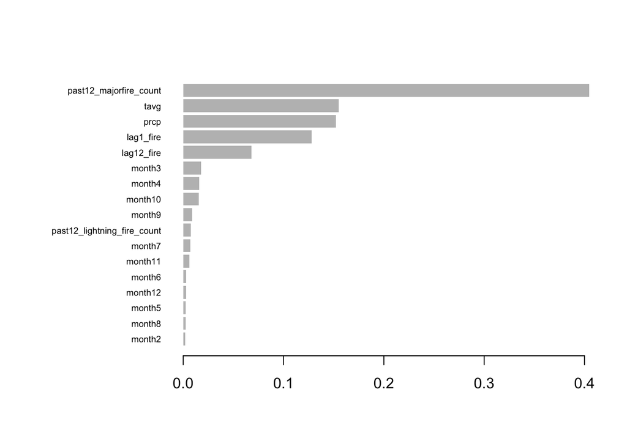

```r
library(xgboost)

importance_matrix = xgb.importance(
  model = xgb_fit
)

xgb.plot.importance(importance_matrix)
```

### Model Comparison

The table below summarizes the performance of the three models on the test dataset. As discussed before, because major wildfires are very rare events, sensitivity is considered very important metrics. AUC is also an important metric as it measures the models’ performance independent of threshold values. Among the three models, XGBoost shows the best overall ability according to AUC, suggesting that XGBoost method may better capture the complex relationship between our predictors and wildfire occurrence. XGBoost model also has a higher sensitivity than the logistic regression baseline model. It means that the XGBoost model is better at identifying actual major wildfires. The speficity of XGBoost model is slightly lower than the baseline regression and Random Forest model, but a 0.9495 speficity also shows the model is doing well in identifying no-major-fire county-month. Though the random forest model has a slightly higher specificity and precision compared to XGBoost, its sensitivity is much lower and thus inferior to XGBoost in this study. Overall Speaking, the XGBoost model is the best among the three models.

```r
glm_auc = roc(test_data$occur, test_data$glm_prob)$auc
glm_auc
```

```
## Area under the curve: 0.845
```

```r
rf_auc = roc(test_data$occur, test_data$rf_prob)$auc
rf_auc
```

```
## Area under the curve: 0.7128
```

```r
xgb_auc = roc(test_data$occur, test_data$xgb_prob)$auc
xgb_auc
```

```
## Area under the curve: 0.8693
```

```r
model_comparison = data.frame(
  Model = c("Logistic Regression", "Random Forest", "XGBoost"),
  Sensitivity = c(sensitivity, sensitivity_rf, sensitivity_xgb),
  Specificity = c(specificity, specificity_rf, specificity_xgb),
  Precision = c(precision, precision_rf, precision_xgb),
  AUC = c(glm_auc, rf_auc, xgb_auc)
)

model_comparison
```

```
##                 Model Sensitivity Specificity Precision       AUC
## 1 Logistic Regression   0.3938538   0.9681596 0.1766756 0.8449596
## 2       Random Forest   0.3239138   0.9795758 0.2157647 0.7127670
## 3             XGBoost   0.4952314   0.9497025 0.1458897 0.8692814
```

To compare the overall classification performance of the models, I also plot the Receiver Operating Characteristic (ROC) curves. An ROC curve shows the tradeoff between sensitivity and the false positive rate across different cutoffs. A model with a curve closer to the upper-left corner has higher sensitivity while keeping the false positive rate low. From the plot we can also see that XGBoost is best at most threshold values.

```r
roc_glm = roc(test_data$occur, test_data$glm_prob)
roc_rf = roc(test_data$occur, test_data$rf_prob)
roc_xgb = roc(test_data$occur, test_data$xgb_prob)
```

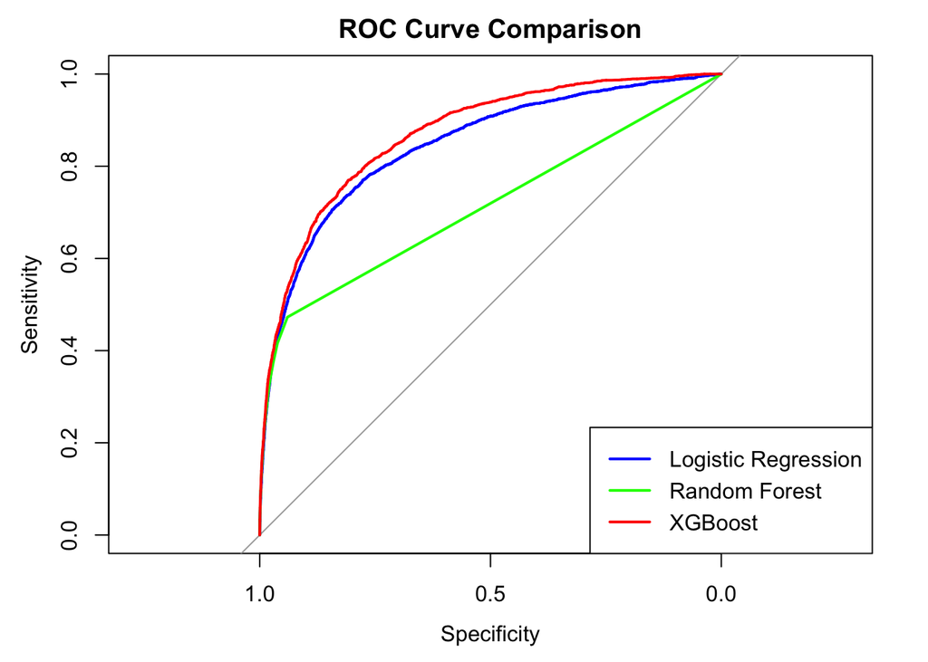

```r
plot(roc_glm, col="blue", main="ROC Curve Comparison")
lines(roc_rf, col="green")
lines(roc_xgb, col="red")

legend("bottomright",
       legend=c("Logistic Regression","Random Forest","XGBoost"),
       col=c("blue","green","red"),
       lwd=2)
```

To further compare model performance across different years, I also compute the Area Under the ROC Curve (AUC) for each model by year. The plot shows the AUC values for each model from 2011 to 2015. Overall, the XGBoost model shows the highest AUC across all years, indicating the strongest predictive performance.

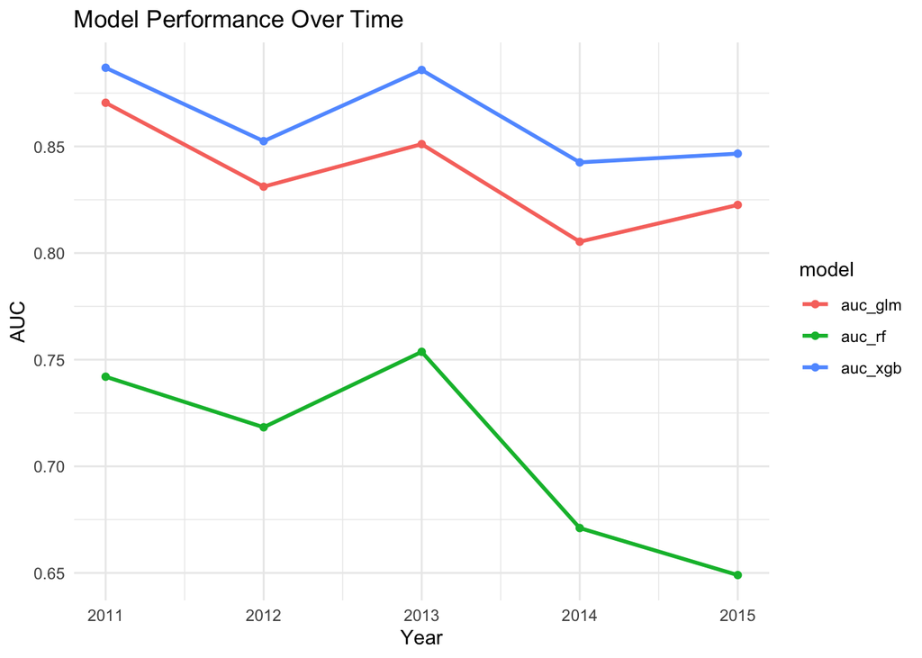

```r
library(dplyr)
library(pROC)

auc_by_year = test_data %>%
  group_by(year) %>%
  summarise(
    auc_glm = as.numeric(pROC::auc(occur, glm_prob)),
    auc_rf = as.numeric(pROC::auc(occur, rf_prob)),
    auc_xgb = as.numeric(pROC::auc(occur, xgb_prob)),
    .groups = "drop"
  )

auc_long = auc_by_year %>%
  pivot_longer(cols = starts_with("auc"),
               names_to="model",
               values_to="auc")

ggplot(auc_long,
       aes(year, auc, color=model)) +
  geom_line(size=1) +
  geom_point() +
  theme_minimal() +
  labs(
    title="Model Performance Over Time",
    y="AUC",
    x="Year"
  )
```

# Summary

The project predicts major wildfire occurrence at the county-month level. I constructed the county-by-month panel dataset from the Kaggle wildfire database and defined the prediction outcome variable as whether at least one major wildfire of at least 300 acres occurred in a given county-month.

My exploratory analysis shows a clear relationship between major wildfire occurrence and seasonality. Nationally, major fire rates are higher during summer months overall. The overall seasonal pattern is not the same across all states though, with Florida, Texas, Arizona, and California each showing different wildfire seasonality. The project also plots the wildfire causes, suggesting that human-related fire causes and natural fire causes contribute to the state-level seasonality differences in major fire rate. Furthermore, there is a clear relationship between major fire rates and monthly average temperature and precipitation. The spatial plots also show that wildfire occurrence is concentrated in particular regions in Southern and Western United States.

For prediction models, logistic regression model, random forest model, and XGBoost model are constructed in this project. Predictors across all models include: Monthly average temperature, precipitation, month, whether a major wildfire occurred in the previous month (lag1_fire), whether a major wildfire occurred in the same month of the previous year (lag12_fire), the number of major wildfires in the past 12 months (past12_majorfire_count), and the number of lightning-caused major wildfires in the past 12 months (past12_lightning_fire_count). Using both sensitivity and AUC as standards, XGBoost performs best overall across all years. The results also suggest that both climate variables and recent wildfire history are important for predicting major wildfire occurrence.

The project has several limitations. Firstly, some wildfire records in the original Kaggle dataset have missing county identifiers, so those records cannot be assigned to a county-month panel dataset and thus are excluded. As a result, the final dataset does not cover every county in the contiguous United States. Also, some wildfire activities that happened in reality might be excluded from my analysis for this reason too. Secondly, some other factors that could contribute to wildfire occurrences are not included in the models, such as wind, humidity, and vegetation. Further studies could be done including these factors to build a model with better predictive performance.